Now we plot bivariate boxplots for each variable with respect to the rating variable. This will help us understand the variations as a class.

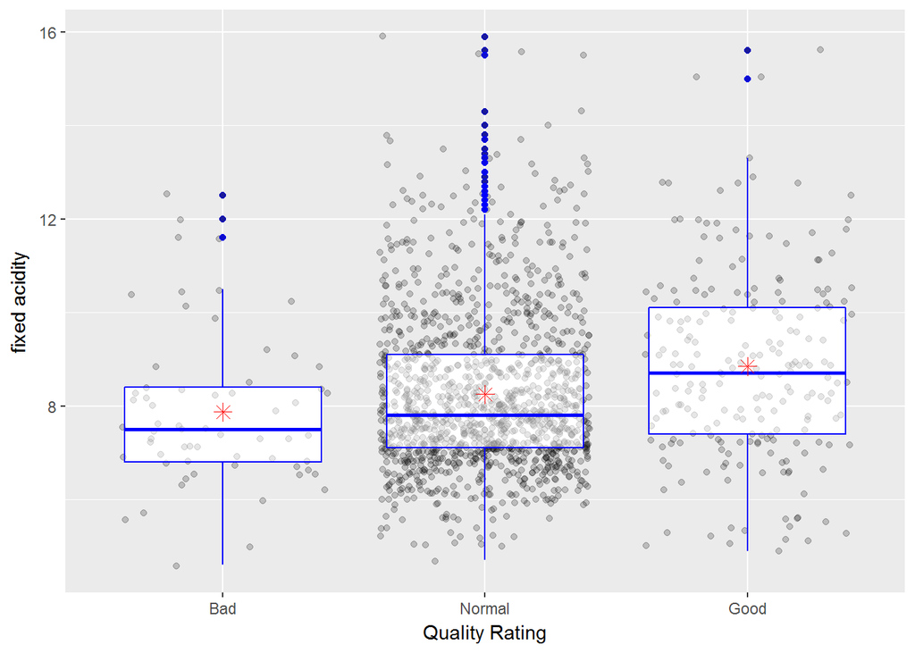

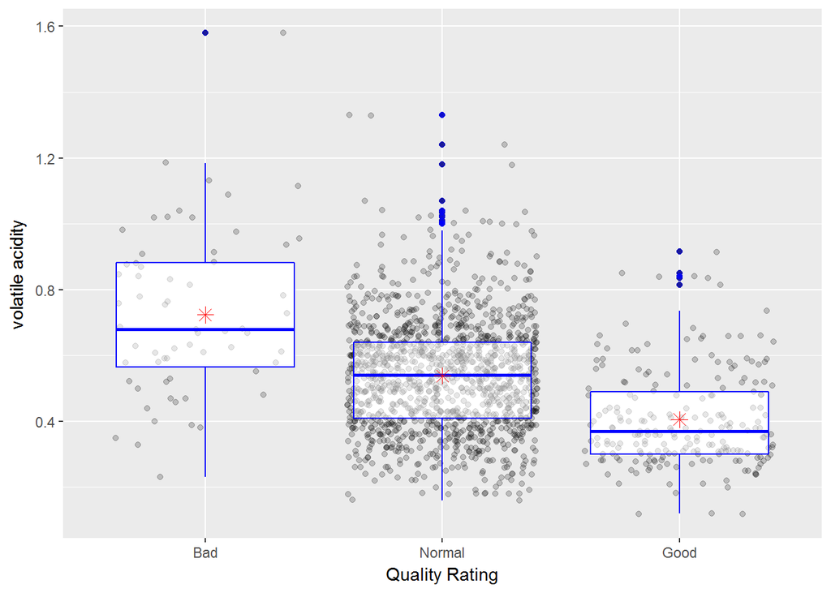

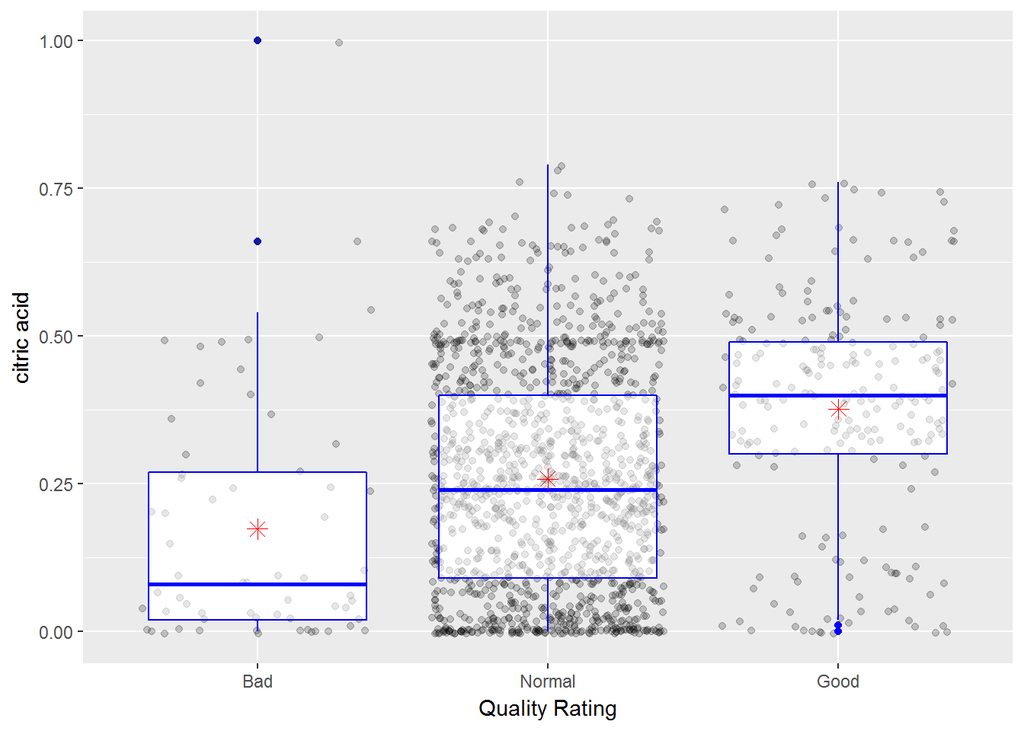

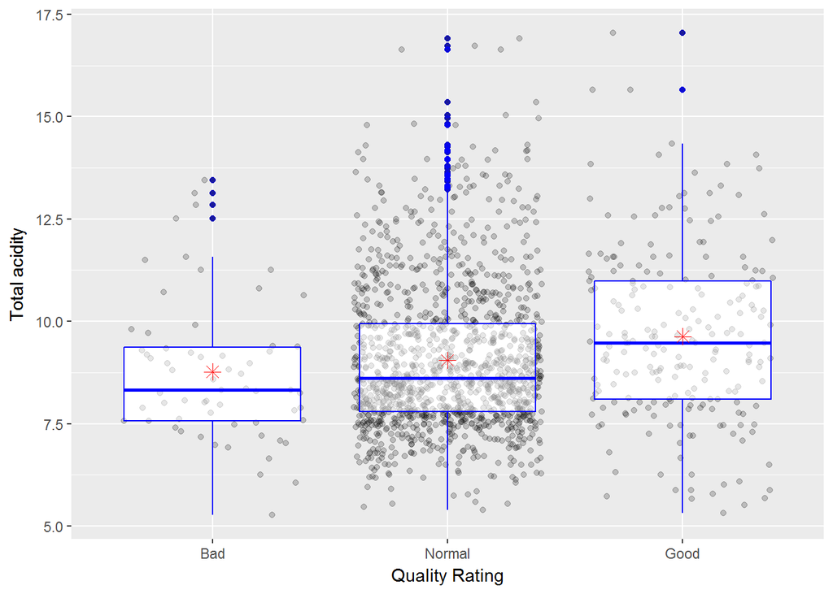

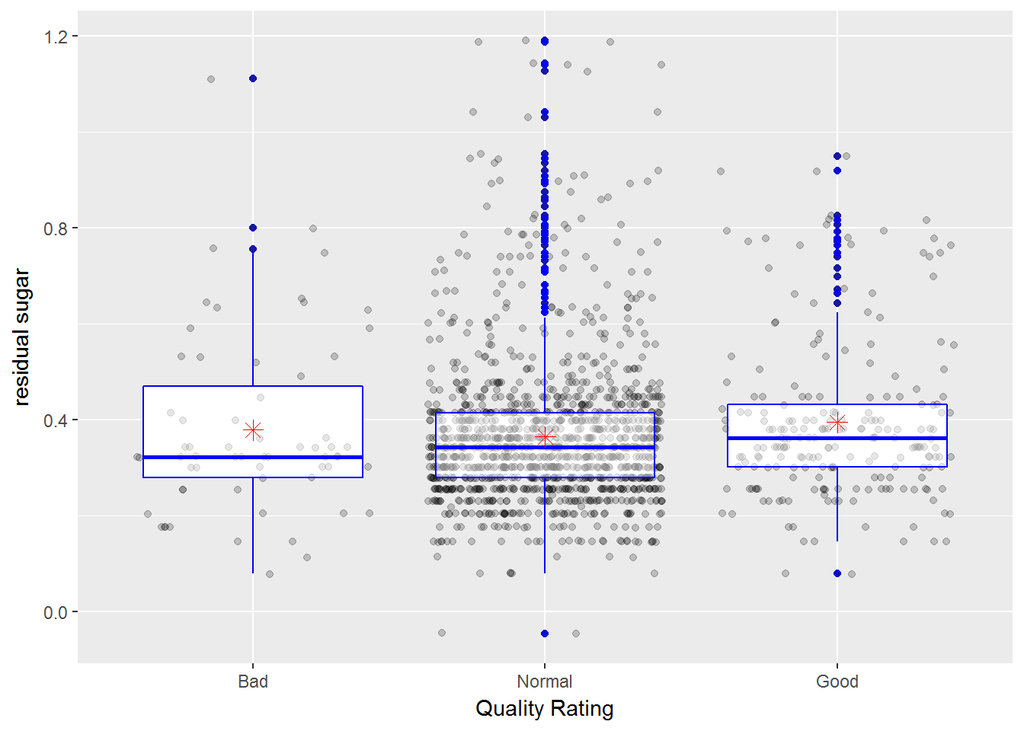

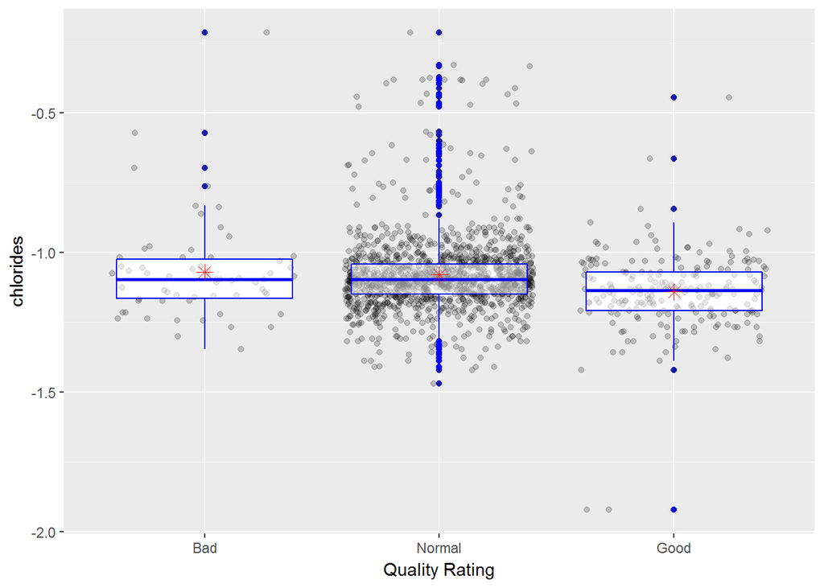

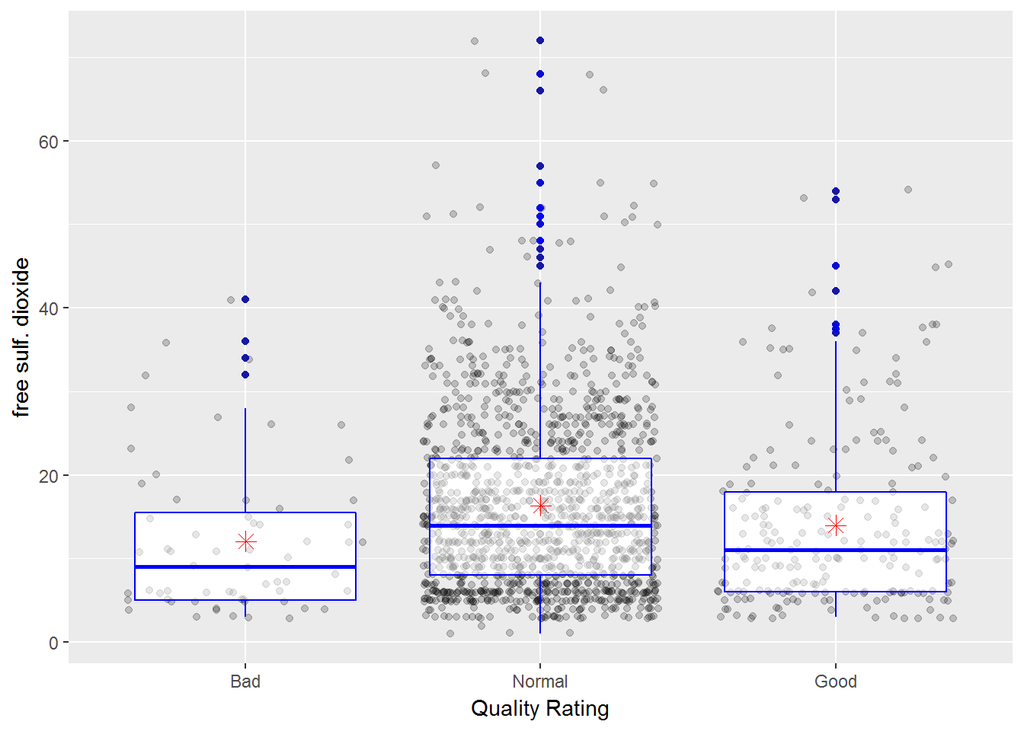

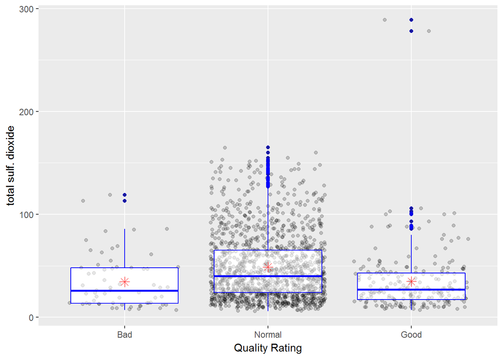

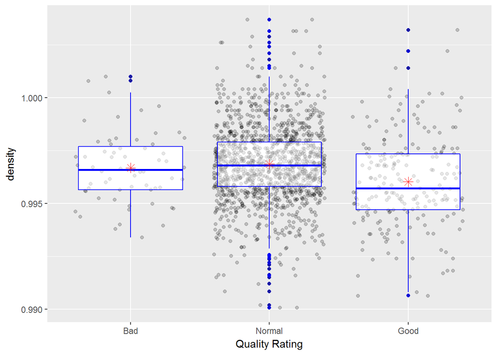

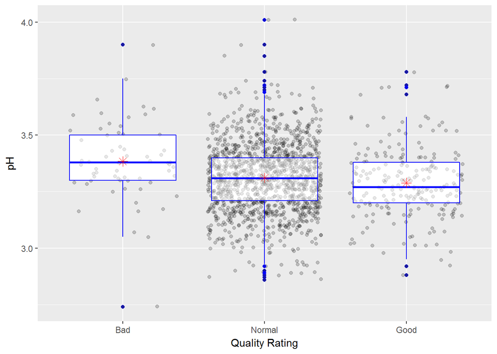

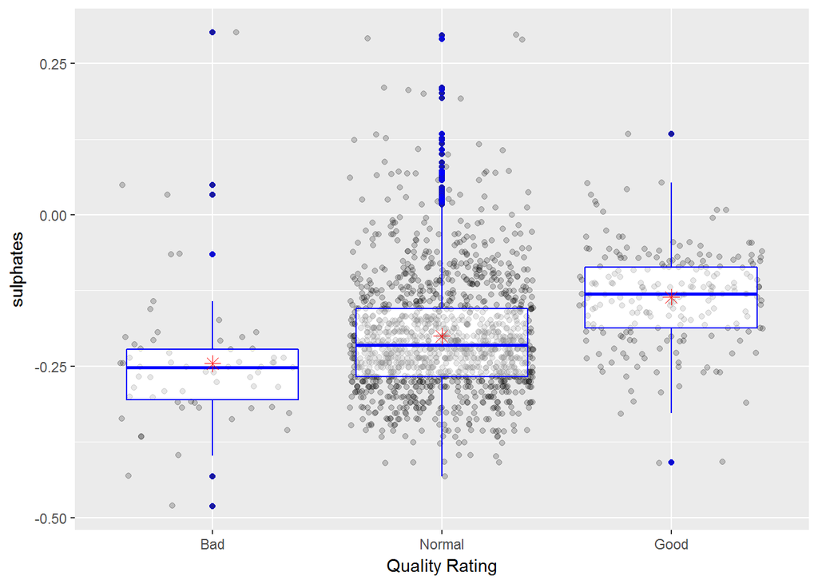

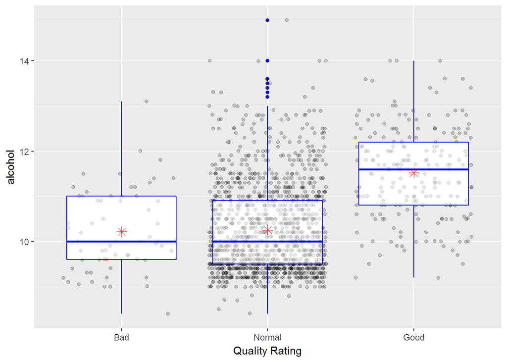

We can confirm our previous results with these generated boxplots. The results we got wrt quality variable stays true for rating variable and makes analysis clearer.

INSIGHTS

Using the above plots, we can theorise a few trends about wine and its constituents. Better wine usually has :  
1. High fixed acidity and low volatile acidity.  
2. Are more acidic in nature (Lower ph).  
3. Higher sulphates and alcohol content.

We will confirm our hypothesis using correlation statistics below.

Its interesting to note that different type of acid affected the wine quality.

Now, I will use correlation ( cor.test) to find correlation for variables against quality variable. This will help us better understand which parameters affect quality more.

```
##        fixed.acidity     volatile.acidity          citric.acid
##           0.12405165          -0.39055778           0.22637251
##        total.acidity log10.residual.sugar      log10.chlordies
##           0.10375373           0.02353331          -0.17613996
##  free.sulfur.dioxide total.sulfur.dioxide              density
##          -0.05065606          -0.18510029          -0.17491923
##                   pH      log10.sulphates              alcohol
##          -0.05773139           0.30864193           0.47616632
```

INSIGHTS

Thus we can see that :  
1.With a correlation coefficient of 0.226, the graph shows a weak positive relationship between quality level and citric acid.  
2.With the correlation coefficient of 0.476, the graph shows a positive relationship between alcohol and quality level.

Now lets plot the variables against each other while faceted by wine rating:

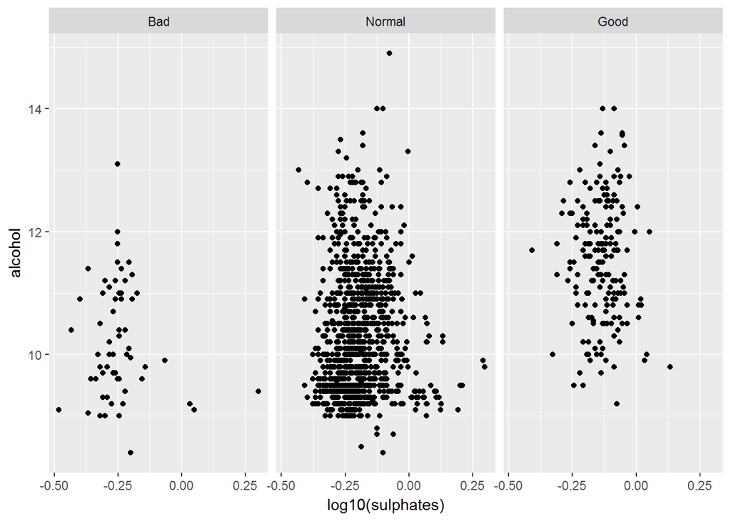

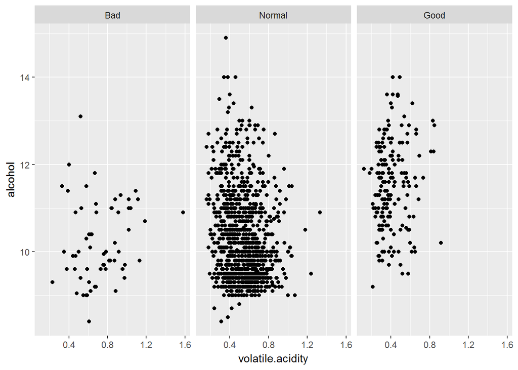

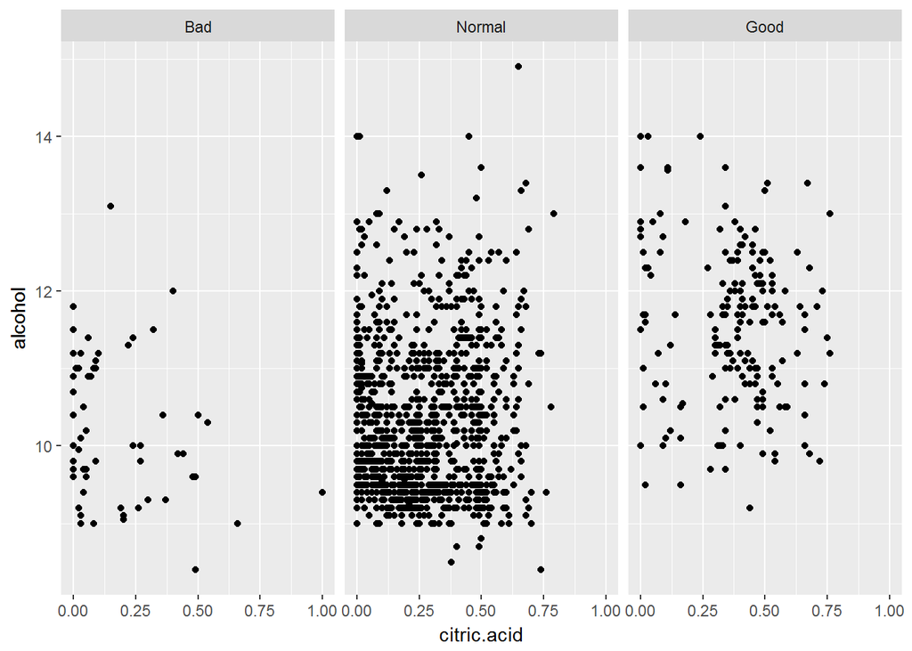

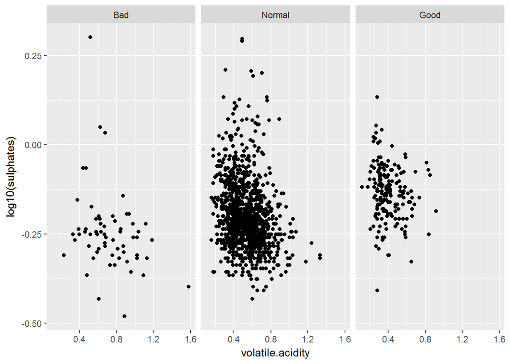

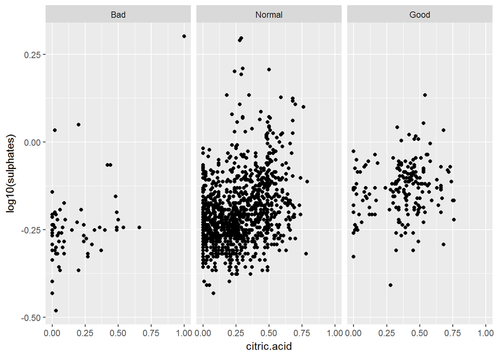

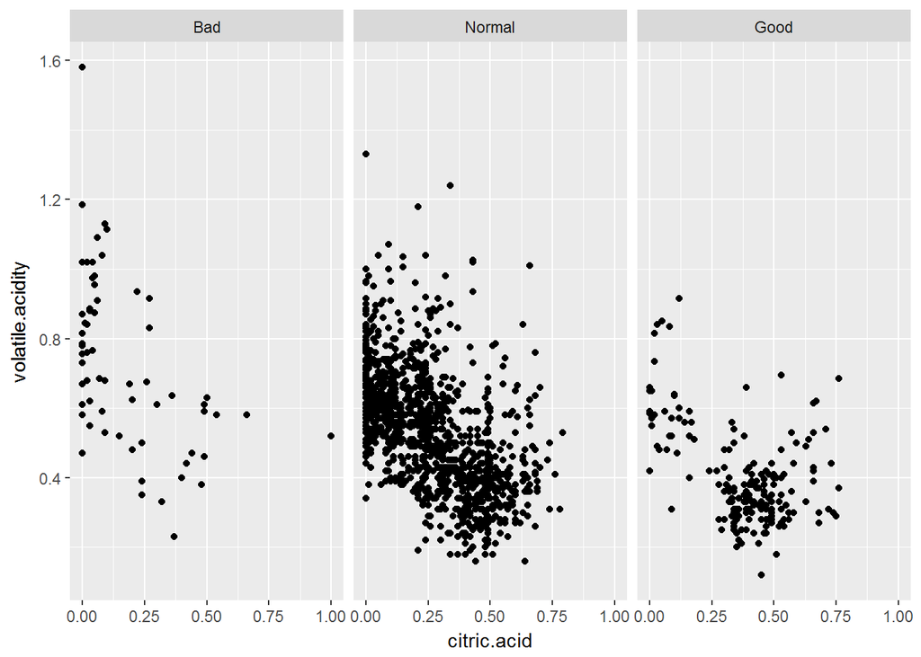

Examining the acidity variables, I saw strong correlations between them:

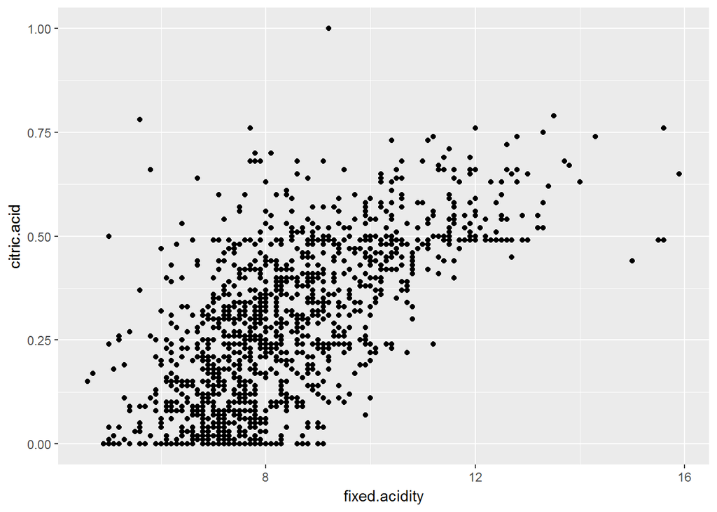

```
##
##  Pearson's product-moment correlation
##
## data:  wine_quality$fixed.acidity and wine_quality$citric.acid
## t = 36.234, df = 1597, p-value < 2.2e-16
## alternative hypothesis: true correlation is not equal to 0
## 95 percent confidence interval:
##  0.6438839 0.6977493
## sample estimates:
##       cor
## 0.6717034
```

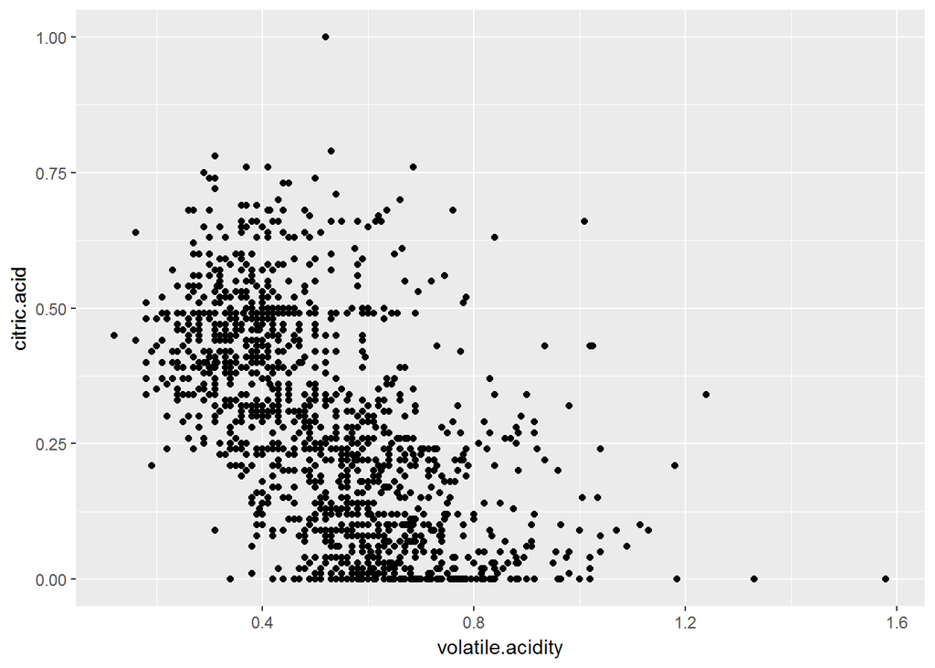

```
##
##  Pearson's product-moment correlation
##
## data:  wine_quality$volatile.acidity and wine_quality$citric.acid
## t = -26.489, df = 1597, p-value < 2.2e-16
## alternative hypothesis: true correlation is not equal to 0
## 95 percent confidence interval:
##  -0.5856550 -0.5174902
## sample estimates:
##        cor
## -0.5524957
```

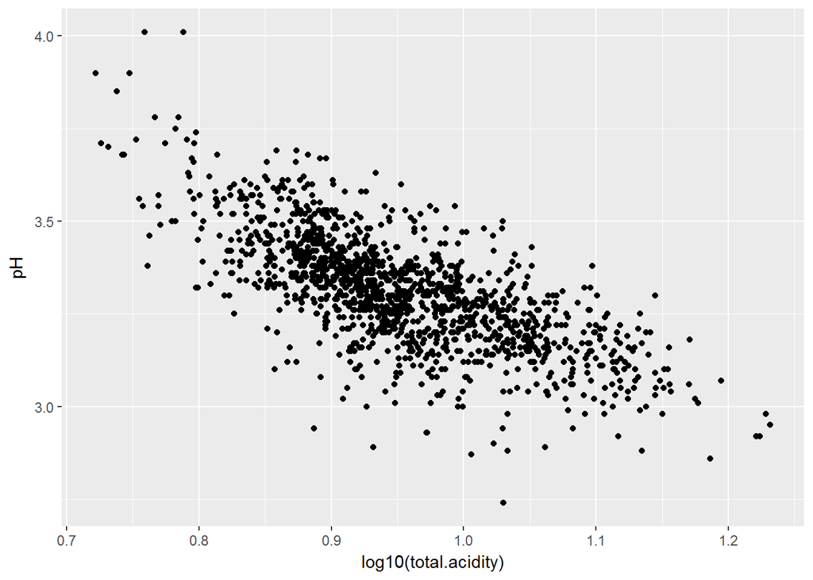

```
##
##  Pearson's product-moment correlation
##
## data:  log10(wine_quality$total.acidity) and wine_quality$pH
## t = -39.663, df = 1597, p-value < 2.2e-16
## alternative hypothesis: true correlation is not equal to 0
## 95 percent confidence interval:
##  -0.7283140 -0.6788653
## sample estimates:
##        cor
## -0.7044435
```

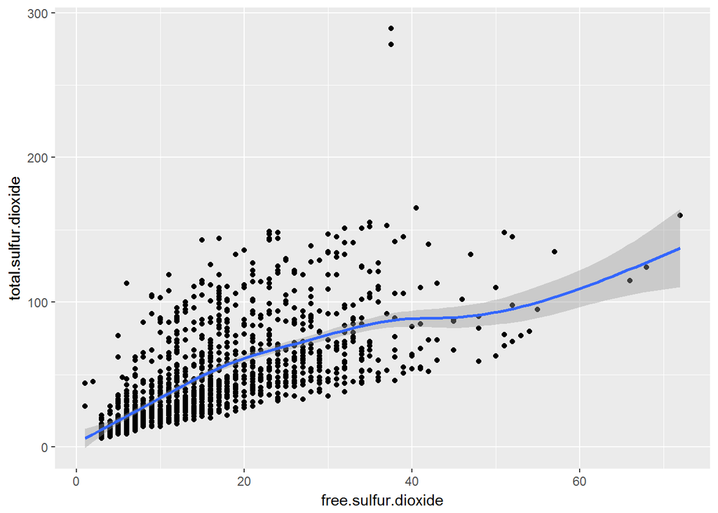

```
##
##  Pearson's product-moment correlation
##
## data:  wine_quality$free.sulfur.dioxide and wine_quality$total.sulfur.dioxide
## t = 35.84, df = 1597, p-value < 2.2e-16
## alternative hypothesis: true correlation is not equal to 0
## 95 percent confidence interval:
##  0.6395786 0.6939740
## sample estimates:
##       cor
## 0.6676665
```

```
##
##  Pearson's product-moment correlation
##
## data:  log10(wine_quality$fixed.acidity) and wine_quality$pH
## t = -39.878, df = 1597, p-value < 2.2e-16
## alternative hypothesis: true correlation is not equal to 0
## 95 percent confidence interval:
##  -0.7301005 -0.6809169
## sample estimates:
##        cor
## -0.7063602
```

```
##
##  Pearson's product-moment correlation
##
## data:  log10(wine_quality$fixed.acidity) and wine_quality$density
## t = 36.537, df = 1597, p-value < 2.2e-16
## alternative hypothesis: true correlation is not equal to 0
## 95 percent confidence interval:
##  0.6471556 0.7006162
## sample estimates:
##       cor
## 0.6747701
```

Thus from the above plots we can conclude,  
1. free.sulfur.dioxide and total.sulfur.dioxide were dependent on each other  
2. logarithm total.acidity correlated very well with pH. This is certainly expected, as pH is essentially a measure of acidity.

Alcohol Content across the classification of our wine dataset.

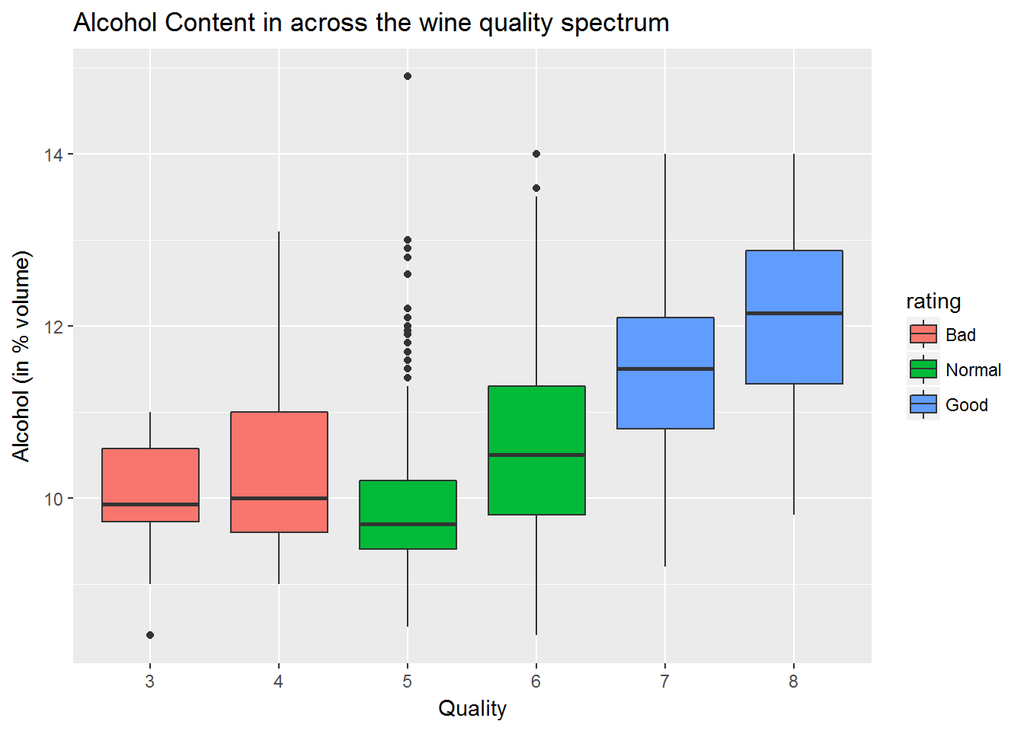

# Bivariate Analysis

### Talk about some of the relationships you observed in this part of the investigation. How did the feature(s) of interest vary with other features in the dataset?

I observed a negative relationships between quality level and volatile acidity, and positive correlation between quality level and alcohol. This makes sense because, because We tend to grade stronger wines as high quality, whereas wines with low percent alcohol are not graded as such. High volatile acidity is also perceived to be undesirable because it negatively impacts the taste of wines. The sulphate measurements have a mild effect on the quality score. This was something I didnt expect.

### Did you observe any interesting relationships between the other features (not the main feature(s) of interest)?

Yes, I observed positive relationship between density and fixed acidity, positive relationship between fixed acidity and citric acid, and negative relationship between pH and fixed acidity.

# Multivariate Plots Section

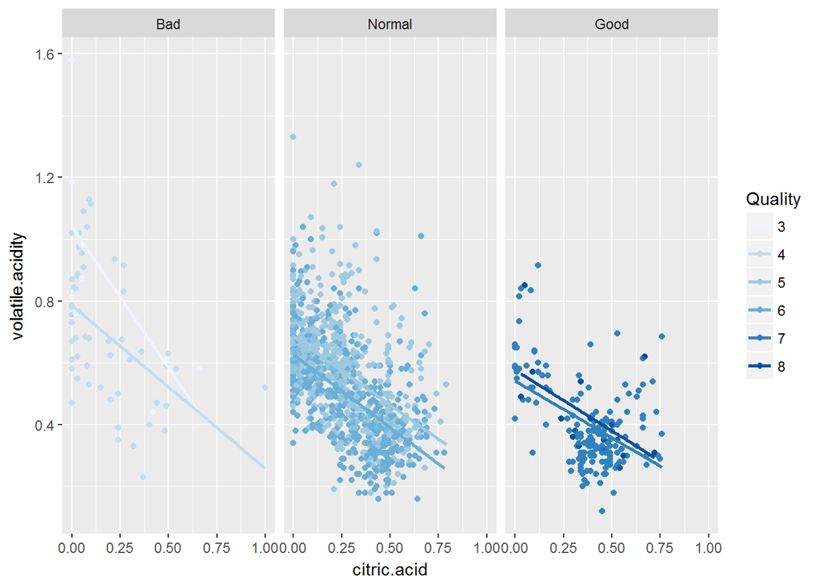

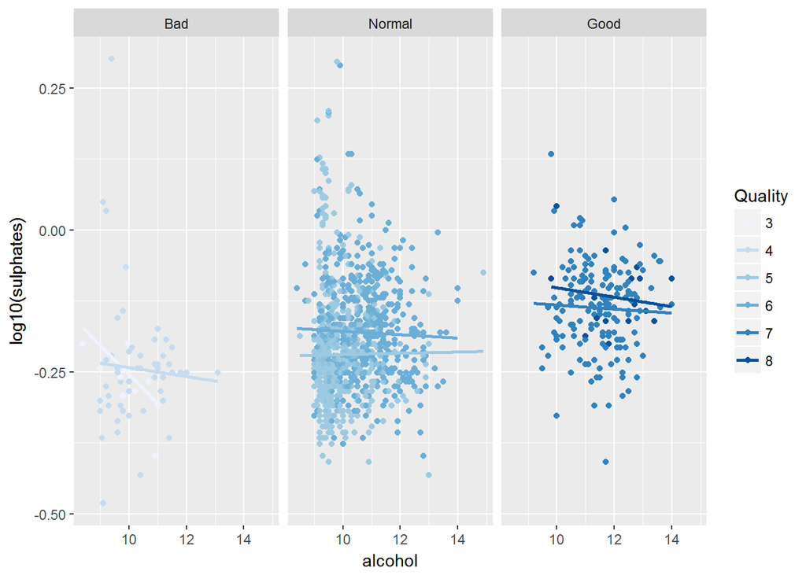

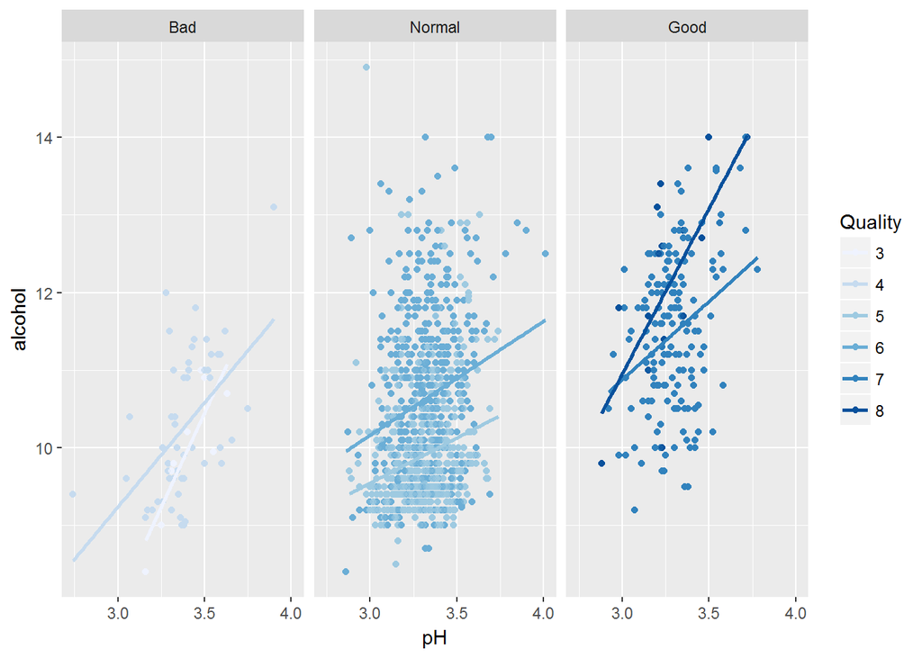

So can we now determine which characteristic affects the quality most and how we might obtain a superior quality of wine ?

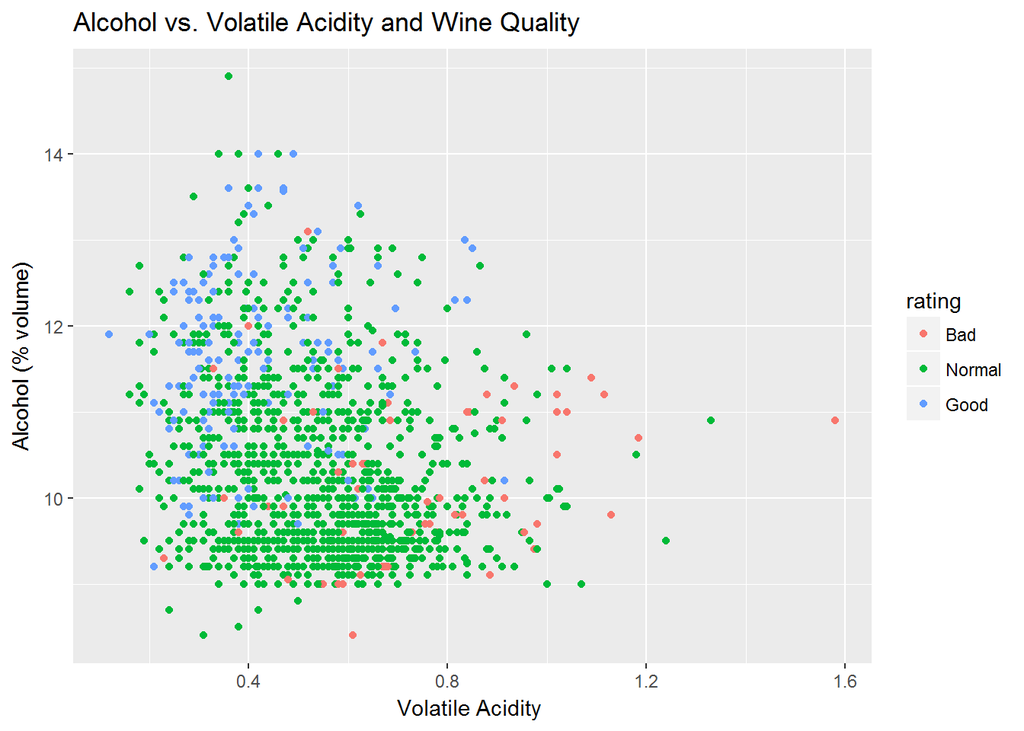

# Multivariate Analysis

It becomes clear using the above plots that good wines have higher citric acid content. Also, better wines also usually have higher alohol content as we can see from the above graphs. Most wines lie between ph of 3 and 3.5, whether good or bad. Alcohol has more effect on the quality of the wine, as seen by the 3rd graph.

### Were there any interesting or surprising interactions between features?

ph has less of an impact on wine quality as its effect is more or less overshadowed by effect of alcohol.

# Final Plots and Summary

### Plot One - Wine quality spectrum

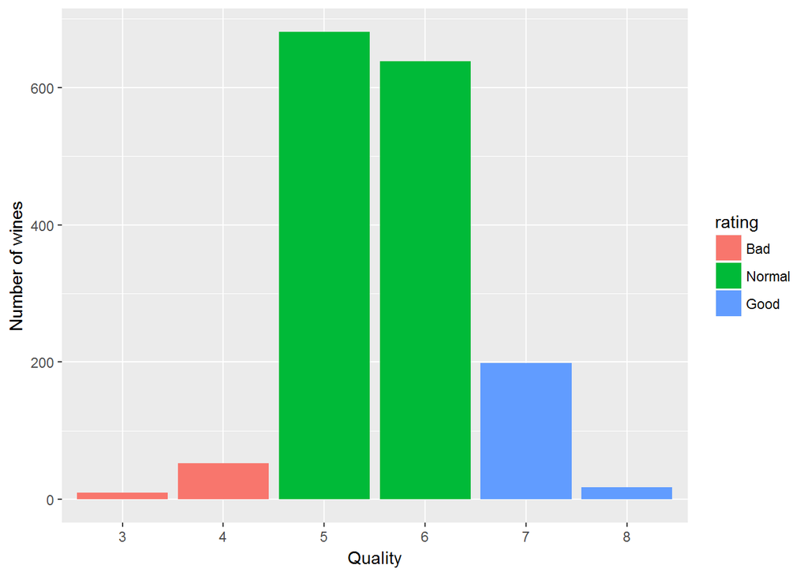

### Description One

The distribution of red wine quality appears to be normally distributed. Most of the wines are rated 5 and 6 (normal or average quality). Even though the rating scale is between 0 and 10, no wine is rated 1, 2, 9 or 10. That is, No one recorded a perfect wine.

### Plot Two - ? Alcohol ? Good ? Bad ?

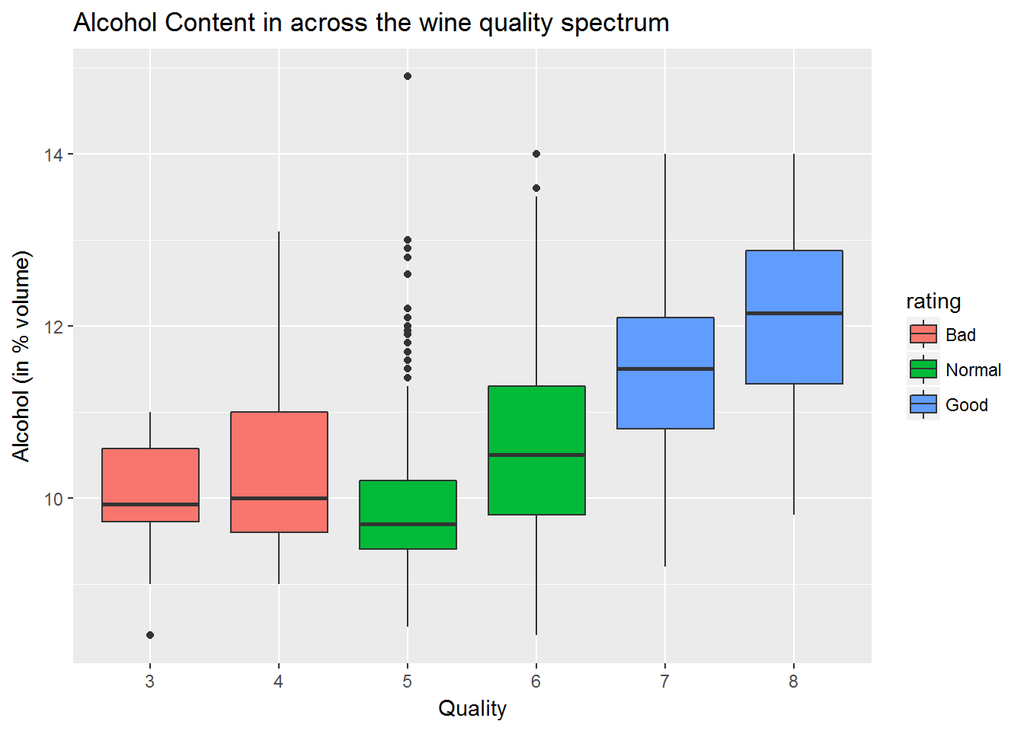

### Description Two

The above boxplot demonstrates the effect of alcohol content on wine quality. Generally, higher alcohol content correlated with higher wine quality. However, as the outliers and intervals show, alchol content alone does not guarantee quality wine.

### Plot Three - How to get a good wine ?

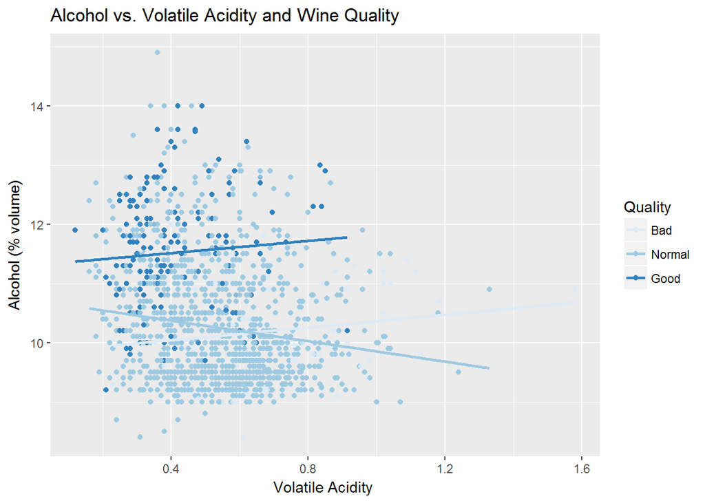

### Description Three

Correlation tests showed that alcohol and volatile acidity was two parameters that affected wine quality. This plot showes us that out of the two, alcohol has more importance. Low volatile acidity is the mark of a good wine and a few outliers of wine with high volatile acidity did have high alcohol content too. In conclusion, we can say that higher alcohol content and a lower volatile acidity can help produce a good wine.

# Reflection

Through this EDA project, I was able to understand the characteristics that determinewine quality, like its alcohol content, sulphates, and acidity level.

It is important to note, however, that wine quality is ultimately a subjective quality, albeit measured by wine experts. A brief reading has led me to understand that while a wine can be differentiated as good and bad usually,even wine tasters differ on extreme cases as each may appreciate different tastes.

The graphs I made adequately illustrate upto a point, factors that can help make good wines ‘good’ and bad wines ‘bad’. More data about wines with quality below 3 and above 7 can be helpful.

### LIMITATIONS

This dataset is incomplete. A more complete dataset can be created if we added information to indicate say, forexample, the type of grapes used, age of the wine etc. Also, working with this kind of dataset would become much easier if you had a domain knowledge about wines and the effect of the constituents. Additional inferential statistics could be done to quantify and confirm the analysis.